# RNA-seq_Plotting

MTM

10/10/2020

# Loading Souce Data

Loaded human log2FC data, normalized counts and sample guide from Posfai’s Plos Pathogens paper, and lncRNA plus gene neighbor lists from Kaessman’s Nature paper.

```r
Hs_Log2FC <- read.csv("source_data/Hs_Log2FC.csv", header = TRUE)
lncRNAs_paper <-read.csv("source_data/lncRNAs_filtered_data_Kaessmann2019.csv", header= TRUE)
norm_counts_all<-read.csv("source_data/Norm_counts_all.csv", header = TRUE)
sample_guide<-read.csv("source_data/SampleGuide_data_dds.csv", header = TRUE)
```

Check data

```r
str(Hs_Log2FC)
```

```
## 'data.frame':    196428 obs. of  7 variables:
##  $ Ensembl.ID      : chr  "ENSG00000149968" "ENSG00000102387" "ENSG00000166510" "ENSG00000139971" ...
##  $ Gene.name       : chr  "MMP3" "TAF7L" "CCDC68" "C14orf37" ...
##  $ log2FoldChange  : num  4.7 3.99 -2.73 3.47 2.42 ...
##  $ pvalue          : num  1.07e-14 3.44e-13 1.89e-12 1.87e-11 1.90e-11 ...
##  $ adjusted.p.value: num  1.76e-10 7.74e-09 4.02e-08 2.10e-07 1.55e-07 6.46e-07 3.43e-07 2.08e-06 2.71e-06 2.71e-06 ...
##  $ Cell.line       : chr  "HepG2" "HepG2" "HepG2" "HepG2" ...
##  $ time.point      : chr  "mid" "late" "early" "late" ...
```

```r
str(lncRNAs_paper)
```

```
## 'data.frame':    182544 obs. of  10 variables:
##  $ X                  : int  1 2 3 4 5 6 7 8 9 10 ...
##  $ XLOC.id            : chr  "Hum_XLOC_000002" "Hum_XLOC_000003" "Hum_XLOC_000004" "Hum_XLOC_000006" ...
##  $ Species            : chr  "Human" "Human" "Human" "Human" ...
##  $ chromosome         : chr  "1" "1" "1" "1" ...
##  $ Dynamic            : logi  FALSE FALSE FALSE FALSE TRUE TRUE ...
##  $ ENSEMBL75.id       : chr  "ENSG00000243485" NA "ENSG00000237094|ENSG00000250575" "ENSG00000237491" ...
##  $ LncRNA.name        : chr  "MIR1302-10" NA "RP4-669L17.10|RP4-669L17.8" "RP11-206L10.9" ...
##  $ Minimum.age        : chr  "multimember_family" "multimember_family" "human-specific" "human-specific" ...
##  $ Genomic.class      : chr  "upstream_sense" "upstream_antisense" "upstream_sense" "downstream_antisense" ...
##  $ Nearest.coding.gene: chr  "ENSG00000186092" "ENSG00000237683" "ENSG00000235249" "ENSG00000269831" ...
```

```r
str(norm_counts_all)
```

```
## 'data.frame':    32738 obs. of  41 variables:
##  $ X         : chr  "ENSG00000243485" "ENSG00000237613" "ENSG00000186092" "ENSG00000238009" ...
##  $ X50001_N_1: num  0 0 0 0 0 ...
##  $ X50000_N_1: num  0 0 0 2.65 0 ...
##  $ X50002_N_1: num  0 0 0 1.73 0 ...
##  $ X50003_N_1: num  0 0 0 0 0 ...
##  $ X50005_N_1: num  0 0 0 2.2 0 ...
##  $ X50006_N_1: num  0 0 1.65 5.79 0 ...
##  $ X50007_N_1: num  0 0 0 4.64 0 ...
##  $ X50008_N_1: num  0 0 0 0 0 ...
##  $ X50009_N_1: num  0 0 0 4.89 0 ...
##  $ X50011_N_1: num  0 0 0 3.29 0 ...
##  $ X50013_N_1: num  0 0 0 1.58 0 ...
##  $ X50014_N_1: num  0.639 0 0 2.557 0 ...
##  $ X50015_N_1: num  0 0 0 6.11 0 ...
```

[output cut: 27 more lines]

```r
str(sample_guide)
```

```
## 'data.frame':    40 obs. of  6 variables:
##  $ X              : chr  "50001_N_1" "50000_N_1" "50002_N_1" "50003_N_1" ...
##  $ count          : num  59.1 72.9 68 64.5 60.9 ...
##  $ Cell.line      : chr  "HuH7" "HuH7" "HuH7" "HuH7" ...
##  $ time.groups    : chr  "early" NA "early" "early" ...
##  $ analysis.groups: chr  "HuH7.early" "HuH7.control" "HuH7.early" "HuH7.early" ...
##  $ time.groups2   : chr  "early" "control" "early" "early" ...
```

# Clean up and transform dataframes

1. Transform categorical data into factors

```r
Hs_Log2FC$Cell.line<-as.factor(Hs_Log2FC$Cell.line)
Hs_Log2FC$time.point<-as.factor(Hs_Log2FC$time.point)
sample_guide$Cell.line<-as.factor(sample_guide$Cell.line)
sample_guide$time.groups2<-as.factor(sample_guide$time.groups2)
```

2. Rename some columns for simplicity.

```r
library(dplyr)
lncRNAs_paper<-rename(lncRNAs_paper, Ensembl.ID=ENSEMBL75.id)
norm_counts_all<-rename(norm_counts_all, Ensembl.ID=X )
sample_guide<-rename(sample_guide, sample.ID=X)
```

#Plotting DEGs

1. Create variables that contain threshold criteria. The lfc.cutoff is set to 0.58; remember that we are working with log2 fold changes so this translates to an actual fold change of 1.5.

```r
### Set thresholds
padj.cutoff <- 0.05
logfc.cutoff <- 0.58
```

2. Create vector that helps us identify the genes that meet our criteria:

```r
threshold<-Hs_Log2FC$adjusted.p.value<padj.cutoff & abs(Hs_Log2FC$log2FoldChange)>logfc.cutoff
```

We now have a logical vector of values that has a length which is equal to the total number of genes in the dataset. The elements that have a TRUE value correspond to genes that meet the criteria (and FALSE means it fails). How many genes are differentially expressed in infected compared to Control, given our criteria specified above? Does this reduce our results?

```r
length(which(threshold))
```

```
## [1] 264
```

To add this vector to our results table we can use the $ notation to create the column on the left hand side of the assignment operator, and the assign the vector to it instead of using cbind():

```r
Hs_Log2FC$threshold<-threshold
```

Now we can easily subset the results table to only include those that are significant using the subset() function:

```r
sig_DE_all<-data.frame(subset(Hs_Log2FC,threshold==TRUE))
```

Subset lncRNAs from sig_DE_all

1. Need to clean up lncRNA table

```r
#check how many lncRNAs are in table from paper
length(lncRNAs_paper$Ensembl.ID)
```

```
## [1] 182544
```

```r
#remove na in r - remove rows - na.omit function / option
lncRNAs_paper <-na.omit(lncRNAs_paper)
#test for NA values
is.na(lncRNAs_paper$Ensembl.ID)
```

[output not shown]

[output cut: 729 more lines]

NA values have been removed.Here I am not sure if I removed IDs that did had an NAs in some other column, but I think it doesn’t matter.

2.Subset lncRNAs

```r
sig_DE_lncRNA <- sig_DE_all[sig_DE_all$Ensembl.ID %in% lncRNAs_paper$Ensembl.ID,]
print(sig_DE_lncRNA)
```

```
##          Ensembl.ID      Gene.name log2FoldChange      pvalue adjusted.p.value
## 7   ENSG00000267934   CTB-176F20.3       3.009213 4.58000e-11      0.000000343
## 46  ENSG00000233246   RP11-415J8.5      -2.985132 9.03000e-07      0.004375660
## 50  ENSG00000224189       HOXD-AS1      -1.381031 1.03000e-06      0.004375660
## 59  ENSG00000245648 RP11-277P12.20       1.907498 1.83000e-06      0.002072254
## 65  ENSG00000260710  RP11-616M22.7       2.475895 2.96000e-06      0.002546216
## 79  ENSG00000264569  RP13-650J16.1      -1.563193 4.36000e-06      0.003363469
## 82  ENSG00000267934   CTB-176F20.3       1.682409 4.73000e-06      0.029937621
## 107 ENSG00000227857    RP4-533D7.5       2.592566 1.13000e-05      0.017175348
## 109 ENSG00000240498     CDKN2B-AS1       1.600369 1.17000e-05      0.006606007
## 127 ENSG00000224093  RP5-1033H22.2      -2.178604 2.14000e-05      0.025271331
## 128 ENSG00000237686  RP5-1120P11.1      -1.477782 2.22000e-05      0.011062147
## 136 ENSG00000266903    CTB-171A8.1      -1.656562 2.57000e-05      0.027349680
## 148 ENSG00000233255     AC019181.2      -1.612433 3.05000e-05      0.014382847
## 161 ENSG00000231721      LINC-PINT      -1.704573 3.81000e-05      0.031147379
```

[output cut: 29 more lines]

#Visualizing DE lncRNAs

Load packages that will be needed

```r
# Load libraries
library(reshape)
```

```r
library(ggplot2)
library(ggrepel)
library(RColorBrewer)
library(pheatmap)
```

Before it gets more complicated, I am going to split my data per cell line.

```r
sig_DE_lncRNA_hepg2<-sig_DE_lncRNA[sig_DE_lncRNA$Cell.line=="HepG2",]
sig_DE_lncRNA_huh7<-sig_DE_lncRNA[sig_DE_lncRNA$Cell.line=="HuH7",]
```

I am going to focus on HepG2 for now

Extract the normalized count values for these genes by subsetting.

```r
sig_DE_lncRNA_hepg2_counts <- norm_counts_all[norm_counts_all$Ensembl.ID %in% sig_DE_lncRNA_hepg2$Ensembl.ID,]
# use first column for row names
sig_DE_lncRNA_hepg2_counts<-data.frame(sig_DE_lncRNA_hepg2_counts,row.names = 1)
```

It worked!

Make a heatmap:

Note that this includes samples for HepG2 and Huh7,yet these are the lncRNAs that are differentially expressed in HepG2.

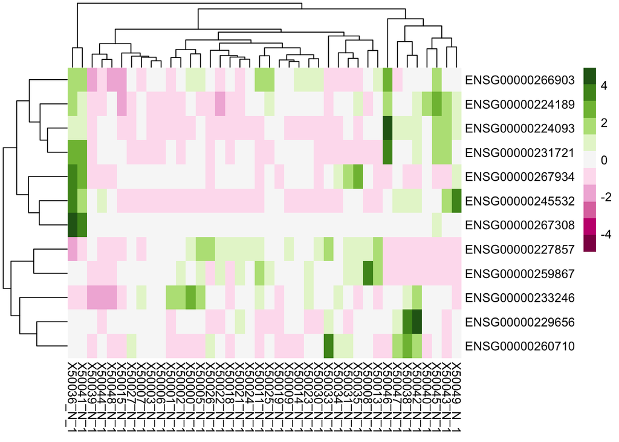

```r
### Set a color palette
 heat.colors <- brewer.pal(11, "PiYG")
### Run pheatmap
pheatmap(sig_DE_lncRNA_hepg2_counts, color = heat.colors, cluster_rows = T, show_rownames=T,
 border_color=NA, fontsize = 10, scale="row",
     fontsize_row = 10, height=20)
```